# Network Anomaly Detection

*Techinical requirements internal document, Guavus, Aug 2016*

## Introduction

Monitoring network systems is of critical importance to Service Providers in maintaining smooth large-scale operations. Efficient measurement of network health and operational status enables QoS guarantees subject to regulatory audits while offering competitive advantages. For instance, traffic volumes reflect the time varying consumer demand and serve as a feedback mechanism on the operational status of the network during faults, attacks and other types of intentional and unintentional aberrations. We tackle the problem of anomaly detection specifically in context of our intended use case of monitoring customer-care calls, the proposed approaches being generally applicable to any form of uni-variate count data, with the intent to generalize to a multi-variate setting to account for the effects of a dynamic and hierarchical nature of an operational network. Early traces of important operational events (such as outages/failures) can be proactively detected by analysing customer-care call volumes and their attributes. Furthermore, insights into the root-cause of any group of events can be gauged and automated for prevention of expensive truck rolls and speedy ticket resolution.

## System Architecture

Care-Reflex is an interactive monitoring device for cable companies to view and quantify trouble events. These trouble events include issues such as technical/information calls, ticketed calls and truck rolls. Care-Reflex provides the ability for the user to select a certain subpopulation of subscribers and view the number of calls or truck rolls coming from that subpopulation in real time, broken up into hourly bins. Effectively, the user gets to see the calls/tickets/truck-rolls plotted as an hourly histogram and is given the further option to break down the volume of calls (or truck rolls) on further attributes/subpopulations.

In addition, a ”baseline” hourly function is plotted in the background for the subpopulation histogram. This ”baseline” indicates the usual number of calls, both as a total for that day of the week, and broken up into hourly bins. The ”usual” or ”baseline” number has been obtained by looking back 5 weeks and extracting the median number of calls for the five samples obtained from that particular subpopulation/day-of-week/hour.

```python
import pandas as pd
import seaborn as sns
sns.set_palette("muted")
%pylab inline
```

```python
import warnings
warnings.filterwarnings('ignore')
np.random.seed(5)
calls = pd.read_csv("/home/prasad/ziggo_anonymize/enriched_call_anonymized.txt")
calls['date_time'] = calls['date_time'].convert_objects(convert_numeric=True).dropna().astype("int").astype("str")
calls = calls.dropna(subset=['date_time','account_id'])
calls['date_hour'] = pd.to_datetime(calls['date_time'].str[:10],format="%Y%m%d%H")
calls['date_time'] = pd.to_datetime(calls['date_time'])
#calls.sample(5)
```

```python
dimensions = ["network_level_1_name","network_level_2_name","network_level_3_name","network_level_4_name",\
              "network_level_5_name","network_level_6_name","network_level_7_name","device_data_manufacturer",\
              "device_data_model","device_video_manufacturer","device_video_model","device_voice_manufacturer",\
              "device_voice_model"]
measures = {"call_id":"count"}

total_calls = calls.groupby("date_hour")[['call_id']].count()
index = pd.date_range(total_calls.index.min(),total_calls.index.max(),freq="H")
total_calls = total_calls.reindex(index).fillna(0)
cols = ['dayofweek','hour']
series = {}
index = pd.DataFrame(zip(total_calls.index.dayofweek,total_calls.index.hour),index=total_calls.index,columns=cols)
period_groups = index.groupby(cols).groups
for dim in dimensions:
    temp = calls.groupby(["date_hour",dim])['call_id'].count().unstack()
    series[dim] = [temp.ix[index] for dayhour,index in period_groups.items()]
series['total'] = [total_calls.ix[index] for dayhour,index in period_groups.items()]
```

## Problem Statement

The network operator is often interested in unusual "bursts" of activity. These bursts may typically span single/multiple attributes (eg. a specific LOB) and at various aggregation levels (eg. hourly/daily/mean shift) depending on the source of anomaly and its manifestation. We aim to quantify the degree of anomalousness, which is assumed to be proportional to the magnitude of this burstiness. Although these methods are applicable to detect anomalies in both directions, however operators are usually interested in the *positive-direction* or unusually higher volumes, ignoring anomalies of unusually lower volumes, therefore our focus lies in the *upper-tails* of the probabilty distribution. These are some constraints under which we are bound to operate:

- **Unsupervised:** Under the assumption that majority of the instances in the data set are normal, i.e. an objective definition for what constitutes "normal", detect instances that seem to fit least to the remainder of the data set, in the absense of any labeling information. Key assumptions in our intended use-case:
  - *Baseline*: Defined to be Median # calls in that hour for the last 5 weeks, Median being a robust measure of centrality that can tolerate ~50% outliers. eg. # calls on Monday 09:00 AM are compared to median # calls from last 5 Mondays 09:00 AM. The assumption of independence and weekly seasonality is implicit here.
  - *Binning*: The current care-reflex implementation is limited to hourly binning and imposes restrictions on the diversity of applicable use-cases, for instance, network attacks being typically very short duration would be rendered undetectable under this constraint. We do not attempt to challenge this practise at the moment, however, addressing this limitation in future would be critical for categorically handling the breadth of anomalies.
- **Online:** Process input piece-by-piece in a serial fashion, in the order that the input is fed to the algorithm, without having the entire input available from the start. These require decisions to be made before all data are available, i.e. at the end of each bin [1].
  - *Complexity:* Under limited memory and processing time constraints, the algorithm must produce an (approximate) answer based on a summary/sketch of the (recent?) data stream in memory for real-time application.

There are some key issues we would like to address as part of the proposed framework for our use-case, i.e. customer-care calls, namely:

### Properties

Some well established empirical observations in the call arrival process are as follows [11]:

- The arrival rate varies considerably with the time of day and exhibits daily, weekly, yearly seasonalities, Overall, a diurnal pattern is evident.
- The total number of calls exhibits overdispersion (variance > mean)
- There is significant positive dependence between arrivals rates in different time periods of the same day

Here is the plot of actual call counts and baseline arrivals for a short period:

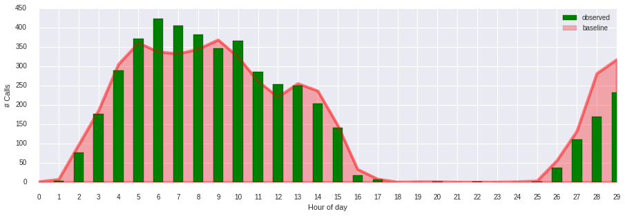

```python
aggregate = pd.concat([pd.concat({"baseline":pd.rolling_median(sub,5).shift(1)['call_id'],"observed":sub['call_id']},\
                                 axis=1) for sub in series['total']]).sort_index()
temp = aggregate[864:894].fillna(0)
temp['observed'].plot(kind="bar",use_index=False,legend=True,color='g')
temp['baseline'].plot(color='r',use_index=False,linewidth=4,alpha=0.3,kind="area",figsize=(15,5),legend=True)
plt.xlabel('Hour of day')
plt.ylabel('# Calls')
sns.despine(offset=10, trim=True)
```

## Methodology

The approches presented fall in the broad domain of statistical methods of anomaly detection, specifically parametric models, wherein the null hypothesis being tested is that a record was generated by a statistical model. The idea is to fit these models to the data and apply an inference test assuming that anomalies occur with low probabilities. There also exist other methods that do not rely on any distributional assumptions outside the statistical realm, these are left for future work.

### 1. A simple threshold

Raw residuals, which we define as: $\epsilon_{i} = observed_{i} - {baseline_{i}}$, are similar to seasonal adjustments to the average call-arrivals by way of absolute differencing ($\bar\epsilon_{i} = 0$). They exhibit skew in either direction depending on different days/hours and are characterised by a heavy center with very long but thinner tails considerably deviated from a gaussian distribution.

An upper bound on these raw-residuals may be arbitrarily inferred from the data. This resolves to making the statement that an anomaly is declared as soon as # calls exceed an absolute threshold over baseline. Some classical methods used in Statistical Process Control to infer thresholds are as follows:

- **Standard Deviation**: Given $\alpha=0.001$ and considering the single (right) tail cutoff for a standard normal distribution, $z\approx3$. Typical thresholds on standard deviation follow naturally. However in case of non-gaussian data corrupted by outliers, standard deviation and thresholds are inflated. With these shortcomings, we need more robust estimators of spread.
  - residual > $3*\hat{\sigma}$
- **Tukey's IQR**: When a data set has outliers, with the underlying distribution assumed symmetric, variability is often summarized by a statistic called the interquartile range [2] used in box-plots [3], which is the difference between the first and third quartiles. Outliers are instances where:
  - residual > $Q75+1.5*IQR$
- **MAD**: Another robust measure of variability is the Median Absolute Deviation [4]. In order to use the MAD as a consistent estimator for the standard deviation $\sigma$, one takes ${\hat {\sigma }}=K\cdot \operatorname {MAD}$. For normally distributed data, $K\approx 1.4826$. In the absence of symmetry, we consider a one-sided MAD, i.e. MAD is computed on the positive deviations, thus outliers are [5]:
  - residual > $3.5*MAD^+$

#### Limitations

Using a threshold on raw-residuals ignores the seasonal structure of variance in the call arrival process. In other words, defining outliers as "x calls exceeding baseline" is too rigid despite adjusting for seasonality in the mean, due to different variance around this mean. Say we observe 500 calls at 10:00 AM and 10 calls at 3:00 AM on average, the threshold (say 80 calls above baseline) would not be flexible enough to accomodate both cases simultaneously, due to the inherent seasonal variance structure.

In order to get around this limitation, we seek a normalization scheme to account for these seasonal effects, i.e. a model adjusted for conditional variance given mean resulting in what is commonly called *studentising* of residuals.

### 2. Binomial Model

We draw an analogy to tossing a coin and recording the number of times heads appears, i.e. a binomial count, and then computing a likelihood of atleast as extreme an observation as the one under consideration under the null hypothesis (coin is fair). Assuming that baseline calling-rate represents the true population parameter for a specified time bin and the # total calls in the (yet unobserved) day is also equal to the baseline, we can compute the likelihood of observing rates at least as extreme as the observed call-rate in the current time-bin under the null hypothesis by using a Binomial Distribution.

$$P(X=k)={\binom {n}{k}}p^{k}(1-p)^{n-k}$$

- $H_0$ = Normal call rate in the specified time bin is x%
- $H_1$ = Normal call rate in the specified time bin is greater than x%

#### Limitations

The probability of complement, i.e. the event of getting Tails, is unobservable and ill-defined, and thus the need for more natural (poisson-like) arrival models. The baseline assumption of normal pre-specified call rate is strong, since it is just another sampled estimate from the 5-week baseline. A variant of the null hypothesis that relaxes this is based on the assumption that the observed and baseline call rates are sampled from the same underlying (but unknown) distribution.

### 3. Fisher Exact Test

In an attempt to relax the limitation that 5-week baseline calling-rates determine the true population parameter for that bin, we assume a random calling rate as opposed to a deterministic value. Then, we test the significance of association (contingency) between # calls in an hour vs. rest of the day, for the current vs. baseline period, i.e. compute likelihood of current observation under the null hypothesis that current and baseline are sampled from the same distribution. We can split the data across two variables, # calls in current hour vs. rest-of-day and the corresponding #calls in baseline:

```
                       Calls      Baseline     Row Total

    Current-Hour       a          b            a + b
    Rest-of-day        c          d            c + d
    Column Total       a + c      b + d        a + b + c + d (=n)
```

We make the same assumption as earlier about the (yet unobserved) # total calls to be equal to that of baseline. To compute the likelihood of a rate at least as extreme as that observed in the current time-bin under the null hypothesis, we use the Fisher exact method. Fisher showed that the probability of obtaining any such set of values was given by the hypergeometric distribution [6]:

$${ p={\frac { {{a+b} \choose {a}} {{c+d} \choose {c}}}{ {{n} \choose {a+c}}}}={\frac {(a+b)!~(c+d)!~(a+c)!~(b+d)!}{a!~~b!~~c!~~d!~~n!}}}$$

- $H_0$ = Current call rate is the same as baseline in the specified bin (=RV X%)
- $H_1$ = Current call rate is greater than baseline in the specified bin

This works remarkably well for small sample sizes thus maintaining robustness during low call arrivals during periods of inactivity. Since this is just a probability, we use its negative logarithm transform as the normalized metric or in other words an "outlier score" that proves effective in ranking anomalous intensity/degree across sub-attributes and times.

#### Limitations

It is conservative to assume that the (yet partially observed) # total calls in the day is equal to baseline, ignoring the # calls that have been observed until the current time. Moreover, this does not take into consideration the observed variance around mean, i.e. it serves solely as a way of comparing first-order statistics, while not providing any flexibility/parameterization on second-order statistics.

```python
from scipy import stats
data = aggregate.dropna()[:1900]
period = data.index
data['fisher_exact'] = 0
for datetime in period:
    obs,baseline_hour = data.ix[datetime][['observed','baseline']]
    baseline_day = data.ix[str(datetime.date())]['baseline'].sum()
    data.loc[datetime,'fisher_exact'] = -np.log(stats.fisher_exact([[obs, baseline_hour], [baseline_day-obs, baseline_day-baseline_hour]], alternative="greater")[1])
```

### 4. Z-Score

The modified z-score is a standardized score similar to "studentized" residuals in linear regression that measures outlier strength or how much a particular observation differs from the typical observation. Using standard deviation units, it approximates the difference of the score from the median. The modified z score is non-parametric and more robust than the standard z score because it relies on the median for calculating the z score, and less influenced by outliers when compared to the standard z score.

It is calculated from the mean absolute deviation (MeanAD) or median absolute deviation (MAD). These values must be multiplied by a constant to approximate the standard deviation. Compute modified z-scores as: $$z = \frac{(x_{i} - \tilde{x})} {K*\operatorname {AbsDev}}$$

Depending on the value of MAD, the modified z score is calculated in one of two ways [7]:

- MAD = 0 => $K\approx1.253$ using the Mean Absolute Deviation
- MAD!= 0 => $K\approx1.486$ using the Median Absolute Deviation

Small counts are handled by simple flooring i.e. $\lfloor{AbsDev}\rfloor=1$ to adjust the extreme-values encountered when $MAD\approx0$. The modified-z being a standardized score is capable of ranking across features and time.

```python
def MAD(x,k=1.4826,twoside=1):
    dev = x - np.median(x)
    if twoside:
        mad= k*np.median(np.abs(dev))
    else:
        mad= k*np.median(np.abs(dev[dev>0]))
    return mad

def mean_AD(x,k=1.253314):
    dev = np.mean(np.abs(x - np.median(x)))
    if dev==0:
        dev = 1.
    return k*dev

def modified_z(curr,data=aggregate['observed'],periods=5):
    base_index = pd.date_range(end=curr,freq="7D",periods=periods+1)[:-1]
    baseline = data.ix[base_index]
    dev = (data.ix[curr] - np.median(baseline))
    if MAD(baseline)!=0:
        modified_z = dev/MAD(baseline)
    else:
        modified_z = dev/mean_AD(baseline)
    return modified_z
```

```python
data['modified_z'] = 0
period = data.index
for datetime in period:
    data.loc[datetime,'modified_z'] = modified_z(curr=datetime,data=data['observed'])
```

### 5. Doubly Stochastic Poisson

From empirical studies, call center arrivals are known to have a variance that is considerably higher than implied by Poisson arrivals (P2). This inconsistency is mitigated by considering a Poisson process with stochastic rate, which results in the number of arrivals N being negative binomial.

However, while estimating independent versions of the model with a-priori mutually different arrival rates, i.e. independent gamma variables, the correlations between the arrival counts in different time periods within the same day are constrained to be zero, which is inconsistent with (P3).

To address the time-varying arrival rate while allowing nonzero correlations, this model postulates that arrivals follow a Poisson process with random arrival rate function $\Lambda(t)$, and the arrival rate function is randomized by a gamma variable [11]:

$$\Lambda(t) = W*f(t), W ∼ Gamma(γ,1)$$

$f$ characterizes the time variation of the arrival rate over a day; $W$ is interpreted as the (unpredictable) “busyness” of a day; $f(t)$ models the time-varying arrival intensity over the course of a day. We make the particular assumption that $W$ is distributed as $Gamma(\gamma, 1)$ with shape parameter $\gamma > 0$ and scale parameter=1. The function $f$ captures the scale of the arrival rate, so there is no loss in generality by taking the gamma scale parameter as one. The motivation for considering this special case is that the joint distribution of arrival counts turns out to be analytically tractable; the negative multinomial distribution:

$$P(X=\{x_1,x_2,..,x_k\}) = \frac{\Gamma{(\gamma+\sum_{1}^{k}{x_i})}}{\Gamma{(\gamma)}*\prod_{1}^{k}{x_i!}}.\Bigg(\frac{1}{1+\sum_{1}^{k}{\lambda_i}}\Bigg)^\gamma.\prod{\Bigg(\frac{\lambda_i}{1+\sum_{1}^{k}{\lambda_j}}\Bigg)^{x_i}}$$

The arrival rate is assumed to be (approximately) piecewise constant, $\lambda_j = \int_{j-1}^{j}{\lambda(t)}$, while computing the joint maximum likelihood estimates of $\gamma$ and $\Lambda$ using 5-weeks of baseline as truly depicting "normal". To quantify "anomalousness" of the observation, compute the conditional likelihood of # calls as extreme as those observed and use a negative log transformation for scale/sign adjustment.

*Parameter Estimation:* The maximum likelihood estimators (MLEs) of parameters of the negative multinomial distribution satisfy a system of equations in analytically closed form, which can be solved using a numerical method like Broyden's.

```python
from scipy.optimize import broyden2
periods = 5.0
curr = '2016-05-13'
def mle(periods=periods,curr=curr,data=aggregate['baseline']):
    train_days = pd.date_range(end=curr,freq="7D",periods=periods)
    train = pd.concat([data.ix[pd.date_range(start=day,periods=24,freq="H")] for day in train_days]).fillna(0)
    daily = train.resample("D",sum).dropna()
    M = daily.max()
    F = lambda l: daily[daily>=l].count()/periods
    constant = np.array([F(l) for l in range(1,int(M)+1)])
    solve = lambda gamma: (constant/np.array([float(gamma+l-1) for l in range(1,int(M)+1)])).sum() - math.log((daily.sum()/(periods*gamma))+1)
    try:
        gamma_hat = broyden2(solve, xin=[1.], f_tol=1e-14)[0]
    except Exception as e:
        print e
        gamma_hat = 10000000.0
    mean_arrivals = [train[train.index.hour==hour].mean() for hour in range(24)]
    lambdas = [arr/gamma_hat if arr>0 else 0.5/gamma_hat for arr in mean_arrivals]
    return [gamma_hat]+lambdas

def negative_multinomial_marginal(obs, lambda_hat, gamma_hat, approx=2000):
    hours = len(obs)
    Q = 1 + sum(lambda_hat[:hours])
    Q_prime = 1 + sum(lambda_hat[:hours-1])
    likelihood = 0
    for x in range(int(obs[hours-1]),approx+1):
        a = math.lgamma(gamma_hat+sum(obs[:-1])+x) - math.lgamma(gamma_hat+sum(obs[:-1])) - math.lgamma(x+1)
        b = (gamma_hat+sum(obs[:-1])+x)*(math.log(Q) - math.log(Q_prime))
        c = x*(math.log(lambda_hat[hours-1]) - math.log(Q_prime))
        likelihood += np.exp(a - b + c)
    return likelihood

def likelihood(obs,date,estimates):
    mle = estimates.ix[date].tolist()
    prob = negative_multinomial_marginal(obs,lambda_hat=mle[1:],gamma_hat=mle[0])
    return prob
```

The possibility of time dependence improves upon independently estimated negative binomial models by imposing a correlation structure and providing analytically tractable estimation procedures on a joint distribution. In addition, the arrival process has fewer parameters than multiple negative binomials for a smoother fit, eg. 25 vs. 48 parameters for 24 time periods. Also, we are estimating the parameters of the distrbution using MLE on 5-weeks of baseline data, thus curbing over-reliance on a single baseline sample. A flooring mechanism similar to z-scores is applied for tackling small counts. As this method returns upper-tail probabilities which are normalized, a similar argument as earlier supports its ability to rank.

An objective evaluation of the methods described above requires prior information about the anomalous process or labels associated with an anomaly. However as mentioned in constraint (C1), due to the absence of any labels like in most anomaly detection tasks, we assume an anomaly generating process and artificially inject anomalies through simulations [12]. With complete control and knowledge of the anomalous process, this serves as a convienient way to generate labels, enabling us to proceed with standard evaluation procedures, such as quantifying precision/recall and deriving appropriate thresholding schemes.

### Anomaly Injection

Using baseline call volumes as *anomaly free*, an anomalous process is simulated and injected. In case the residuals are normally distributed, an outlier may be considered as any observation exceeding $\mu+3\sigma$, or in case of any symmetric distribution, exceeding $Q75 + 1.5 IQR$ (ordinary box-plot fences) [3]. However, in order to account for the observed skew without the need for making any distributional assumptions, we rely on the non-paramteric *medcouple* statistic [9] used frequently in adjusted box-plots as an estimator for skew. For a medcouple value of $MC$, the lengths of the upper whiskers are defined to be:

$$\Theta = {\Bigg\{{\begin{matrix}1.5IQR\cdot e^{3MC}\ {\text{ if }}MC\geq 0\\1.5IQR\cdot e^{4MC}\ {\text{ if }}MC< 0\end{matrix}}}$$

A general non-parametric definition of an outlier naturally follows from the adjusted whiskers [10] as any observation exceeding the sum of upper quartiles and whisker lengths. The injection process then amounts to replacing baseline volumes corresponding to the top-n anomalies ranked by the medcouple statistic $MC$ with this definition of outliers for varying degrees of anomalous intensity, and can thus be defined as:

$$\epsilon_{i} = {\Bigg\{{\begin{matrix}Q75_{i} + k_{i}\cdot\Theta_{i} &{\text{ if }}n_{i}=1 \\ baseline_{i} &{\text{ if }} n_{i}=0 \end{matrix}}}$$$$\{k_{i}\} = [1,2,3]$$

where $n_{i}$ is the anomaly label corresponding to the top $n=\{100,200,300\}$ observations ranked on $MC$ ; $k_{i}$ represents the degree of anomalousness and assumes three discrete values corresponding to 'low', 'medium' and 'high' intensities. The anomalous process is simulated by computing $IQR$ and $Q75$ of the corresponding date/time baseline counts for the previous 3-weeks, and then injected to obtain multiple test sets over varying abundance of outliers (degree of corruption) and intensities (degree of outlyingness). The assumption of independence between different days of the week and hours is implicit, i.e. the anomaly is injected solely based on historical statistics of current day of week and hour of observation ignoring other days/hours.

```python
from statsmodels.stats.stattools import medcouple

def adj_whiskers(sample):
    mc = medcouple(sample)
    iqr = np.subtract(*np.percentile(sample, [75, 25]))
    iqr = 5. if iqr<5 else iqr
    whisker = np.exp(3*mc)*1.5*iqr if mc>0 else np.exp(4*mc)*1.5*iqr
    return mc,np.ceil(whisker)
```

```python
period = 3
base = aggregate[['baseline']].dropna()
base['whisker'],base['75%'],base['mc'] = np.nan,np.nan,np.nan
for hour in range(24):
    for day in range(7):
        sub = base[base.index.hour==hour]
        sub = sub[sub.index.dayofweek==day]
        base['whisker'].fillna(pd.rolling_apply(sub['baseline'],period,lambda x: adj_whiskers(x)[1]).shift(1),inplace=True)
        base['mc'].fillna(pd.rolling_apply(sub['baseline'],period,lambda x: adj_whiskers(x)[0]).shift(1),inplace=True)
        base['75%'].fillna(pd.rolling_apply(sub['baseline'],period,lambda x: np.ceil(np.percentile(x,75)) if np.percentile(x,75)>0 else 1.).shift(1),inplace=True)

anomaly = {}
for p in range(1,4):
    index = base.sort(['mc'],ascending=False)[:100*p].index
    base["anomaly_top%s"%(p*100)] = 0
    base.loc[index,'anomaly_top%s'%(p*100)] = 1
    for k in range(1,4): base[k] = base['whisker']*k + base['75%']
```

## Results

We first examine the results of fitting the doubly stochastic poisson model, consider the estimated mean and variance of call arrival rates for major business hours as shown below. Strong seasonal patterns emerge in the call arrival process by hour of the day, some observations that are evident from the plots below are as follows:

- Call-arrivals show characteristic peaks on mondays and wednesdays.
- Monday witnesses consistently high volumes during the first-half, while the latter-half is (inconsistently) busy on wednesdays.
- Lower volumes are to be expected on weekends and there is not much variation in this pattern.

```python
%%time
period = pd.date_range(start=data.index.date[0],end=data.index.date[-1],freq="D")
estimates = []
for time in period[5*7:]:
    estimates.append(mle(curr=time,data=data['baseline']))

estimates = pd.DataFrame(estimates,index=period.values[35:])
data['double_stochastic'] = 1
for date in period[5*7:]:
    time_range = pd.date_range(start=date,periods=24,freq="H")
    obs = data.ix[time_range]
    for time in time_range:
        if time in data.index:
            data.loc[time,'double_stochastic'] = -np.log(likelihood(obs[:time]['observed'].dropna().tolist(),date=date,estimates=estimates))
```

```
CPU times: user 6min 13s, sys: 250 ms, total: 6min 13s
Wall time: 6min 13s
```

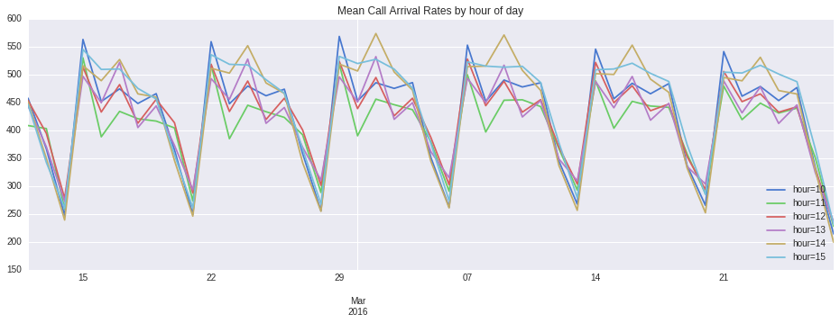

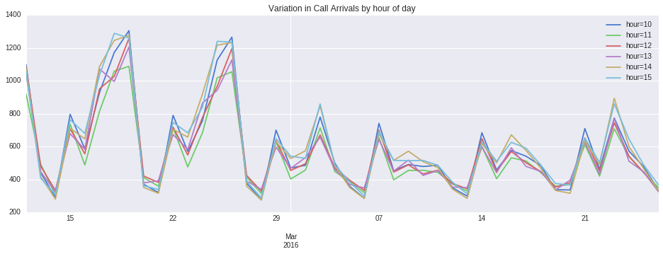

```python
for i in range(1,25):
    a = estimates[0].mul(estimates[i])
    if a.mean()>400:
        a.plot(figsize=(16,5),label="hour=%s"%(i-1),legend=True)
plt.title("Mean Call Arrival Rates by hour of day")
fig = plt.figure()
var = estimates.apply(lambda x:x[0]*x[1:]*(1+x[1:]),axis=1)[:-1]
var.T[var.mean()>530].T.plot(figsize=(16,5),legend=True)
plt.title("Variation in Call Arrivals by hour of day")
plt.legend(labels=["hour=%s"%i for i in range(10,16)])
```

Next, each of the proposed approaches is evaluated against the injected test-sets on three fronts: First, by using simple classification metrics such as precision and recall in a one-vs-all paradigm to compare the efficacy of anomaly detection independently in each scenario and to determine appropriate thresholds. Second, to contrast the ranking ability using ordinal measures of association, such as Kendall's tau rank correlation coefficient, given true information about the degree of outlyingness. Finally, by inspecting their sensitivity to the presence of small counts in the data i.e. during periods of usual inactivity.

```python
%%time
out = {}
observed = base['baseline'].copy()
for p in range(1,4):
    dat = {}
    for intensity in range(1,4):
        # Construct baseline
        observed.loc[base['anomaly_top%s'%(100*p)]==1] = base[intensity]
        baseline = []
        for day in range(7):
            for hour in range(24):
                sub = observed[observed.index.dayofweek==day]
                sub = sub[sub.index.hour==hour]
                baseline.append(pd.rolling_median(sub,5).shift(1))
        sub = pd.concat({"baseline":pd.concat(baseline).sort_index(),"observed":observed},axis=1).dropna()

        # Estimate models over baseline and compute scores
        sub['fisher_exact'] = 0
        period = sub.index
        for datetime in period:
            obs,baseline_hour = sub.ix[datetime][['observed','baseline']]
            baseline_day = sub.ix[str(datetime.date())]['baseline'].sum()
            sub.loc[datetime,'fisher_exact'] = -np.log(stats.fisher_exact([[obs, baseline_hour], [baseline_day-obs, baseline_day-baseline_hour]], alternative="greater")[1])

        sub['modified_z'] = 0
        for datetime in period:
            sub.loc[datetime,'modified_z'] = modified_z(curr=datetime,data=sub['observed'])

        period = pd.date_range(start=sub.index.date[0],end=sub.index.date[-1],freq="D")
        estimates = []
        for time in period[5*7:]:
            estimates.append(mle(curr=time,data=sub['baseline']))

        estimates = pd.DataFrame(estimates,index=period.values[35:])
        sub['double_stochastic'] = 1
        for date in period[5*7:]:
            time_range = pd.date_range(start=date,periods=24,freq="H")
            obs = sub.ix[time_range]
            for time in time_range:
                if time in sub.index:
                    sub.loc[time,'double_stochastic'] = -np.log(likelihood(obs[:time]['observed'].dropna().tolist(),date=date,estimates=estimates))
        dat[intensity] = sub.sort_index()
    out[p] = pd.concat(dat,axis=1)
```

### Thresholding

We choose a threshold based on an appropriate trade-off between the precision and recall classification metrics on a test set with labeled instances. The idea is to determine a threshold which maximizes recall given an upper limit on the False Positive Rate for each of the three methods. We then go on to compare the methods in terms of predictive/detection performance with this choice of thresholds.

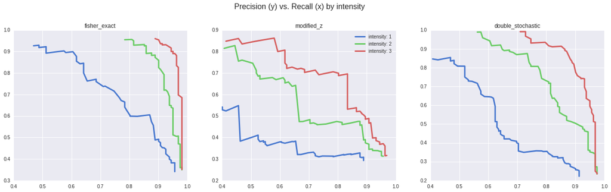

```python
fig,axes = plt.subplots(1,3,figsize=(22,6))
fig.suptitle("Precision (y) vs. Recall (x) by intensity",fontsize=16)
fig.subplots_adjust(top=0.85)
bins = [pow(1.03,i) for i in range(-10,200)]
methods = ['fisher_exact','modified_z','double_stochastic']
start = '2016-03-18 00:00:00'
drop = aggregate['2016-04-16 00:00:00':].index
i=0
for method in methods:
    for intensity in range(1,4):
        pr,re = [],[]
        for bi in bins:
            TP,det,total = 0,0,0
            for p in range(1,4):
                temp = pd.concat([out[p][intensity][method],base['anomaly_top%s'%(100*p)]],axis=1)[start:].drop(drop)
                TP += temp[temp[method]>bi]['anomaly_top%s'%(100*p)].sum()
                det += temp[temp[method]>bi]['anomaly_top%s'%(100*p)].count()
                total += temp['anomaly_top%s'%(100*p)].sum()
            a = TP/float(det) if det>0 else None
            b = TP/float(total) if total>0 else None
            pr.append(a if b>0.4 and a<1 else None)
            re.append(b if b>0.4 and a<1 else None)
        axes[i].plot(re,pr,label="intensity: %s"%intensity,lw=3)
        axes[1].legend(), axes[i].set_title(method)
    i+=1
```

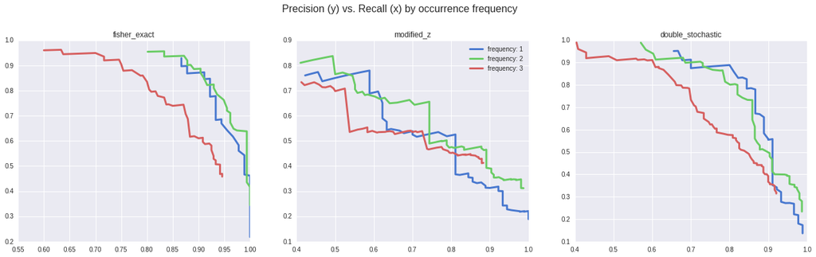

```python
fig,axes = plt.subplots(1,3,figsize=(22,6))
fig.suptitle("Precision (y) vs. Recall (x) by occurrence frequency",fontsize=16)
fig.subplots_adjust(top=0.85)
i=0
for method in methods:
    for p in range(1,4):
        pr,re = [],[]
        for bi in bins:
            TP,det,total = 0,0,0
            for intensity in range(1,4):
                temp = pd.concat([out[p][intensity][method],base['anomaly_top%s'%(100*p)]],axis=1)[start:].drop(drop)
                TP += temp[temp[method]>bi]['anomaly_top%s'%(100*p)].sum()
                det += temp[temp[method]>bi]['anomaly_top%s'%(100*p)].count()
                total += temp['anomaly_top%s'%(100*p)].sum()
            a = TP/float(det) if det>0 else None
            b = TP/float(total) if total>0 else None
            pr.append(a if b>0.4 and a<1 else None)
            re.append(b if b>0.4 and a<1 else None)
        axes[i].plot(re,pr,label="frequency: %s"%p,lw=3)
        axes[1].legend(), axes[i].set_title(method)
    i+=1
```

The observation is that fisher's method gives the best overall detection performance in terms of precision-recall trade-off followed closely by the doubly-stochastic model and finally z-scores, across all test cases.

### Ranking

In order to depict the fuzziness in thresholding, we first examine the box-plots for each of the methods by the true intensity used in the injection process. A formal quantification and comparison of ranking ability is then done by using the Kendall's tau-b metric. It is a statistic used to measure the ordinal association between two measured quantities, more specifically, it defines the similarity of the orderings of the data when ranked by each of the quantities.

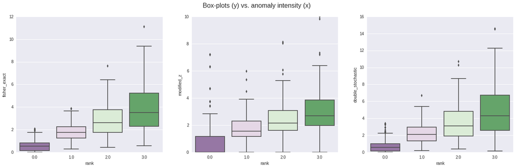

```python
fig,axes = plt.subplots(1,3,figsize=(22,6))
fig.suptitle("Box-plots (y) vs. anomaly intensity (x)",fontsize=16)
methods = ['fisher_exact','modified_z','double_stochastic']
tau = {}
fig.subplots_adjust(top=0.9)
i=0
for method in methods:
    tau[method] = []
    for p in range(1,4):
        temp = out[p].drop(drop).stack(0).drop_duplicates().reset_index().set_index("level_0").dropna()
        temp = pd.concat({"rank":temp['level_1'].mul(base['anomaly_top%s'%(100*p)]).dropna(),method:temp[method]},axis=1).dropna()
        tau[method].append(stats.kendalltau(temp[temp['rank']>0]['rank'],temp[temp['rank']>0][method])[0])
    sns.boxplot(x="rank", y=method, data=pd.concat([temp[method].apply(np.sqrt),temp['rank']],axis=1), palette="PRGn",ax=axes[i])
    i+=1
```

It is evident from the box-plots above that both fisher's method and doubly-stochastic models give fairly seperable distributions across anomaly ranks: $[0,1,2,3]$ representing no anomaly, low, medium, and high intensity anomalies respectively. Modified-z scores seemingly work well in distinguishing between low, medium and high intensities, however there is disproportionate skew within non-anomalous observations especially due to its sensitivity to low-count cases.

This is confirmed by checking the rank correlations for each of the methods across frequencies of anomaly occurrence, and the results are similar to those from precision-recall evaluations. Fisher again showing highest ordinal association followed by doubly-stochastic and modified-z scores:

```python
frame = pd.DataFrame(tau,index=["top_%s_anomalies"%(i*100) for i in range(1,4)])
print frame
```

```
                   double_stochastic  fisher_exact  modified_z
top_100_anomalies           0.518187      0.547381    0.336985
top_200_anomalies           0.457426      0.508723    0.321112
top_300_anomalies           0.332310      0.380464    0.267491
```

Here is a visual display of the methods in action by assuming thresholds which correspond to $\approx 80\%, 70\%, 60\%$ precision and recall on low intensity anomalies for fisher's method, double stochastic and modified-z score respectively:

```python
p = 2
intensity = 1
pr,re = {},{}
for method in methods:
    pr[method],re[method] = [],[]
    for bi in bins:
        TP,det,total = 0,0,0
        temp = pd.concat([out[p][intensity][method],base['anomaly_top%s'%(100*p)]],axis=1)[start:].drop(drop)
        TP += temp[temp[method]>bi]['anomaly_top%s'%(100*p)].sum()
        det += temp[temp[method]>bi]['anomaly_top%s'%(100*p)].count()
        total += temp['anomaly_top%s'%(100*p)].sum()
        a = TP/float(det) if det>0 else np.nan
        b = TP/float(total) if total>0 else np.nan
        pr[method].append(a)
        re[method].append(b)
val = {}
for method in methods:
    temp = pd.concat({"threshold":pd.Series(bins),"recall":pd.Series(re[method]),"precision":pd.Series(pr[method])},axis=1).dropna()
    temp = temp[temp<>0]
    temp['diff'] = temp['precision'].subtract(temp['recall'])
    val[method] = temp.ix[temp['diff'].apply(np.abs).idxmin()][['precision','recall','threshold']]
print pd.concat(val,axis=1)
```

```
           double_stochastic  fisher_exact  modified_z
precision           0.679245      0.788462    0.580000
recall              0.692308      0.788462    0.557692
threshold           4.256219      2.287928    4.011895
```

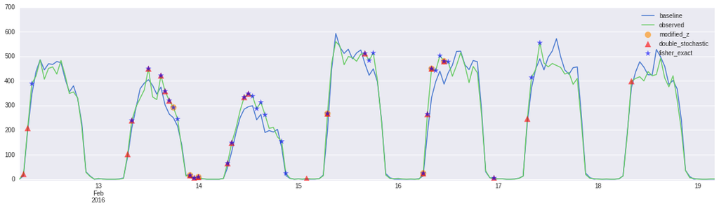

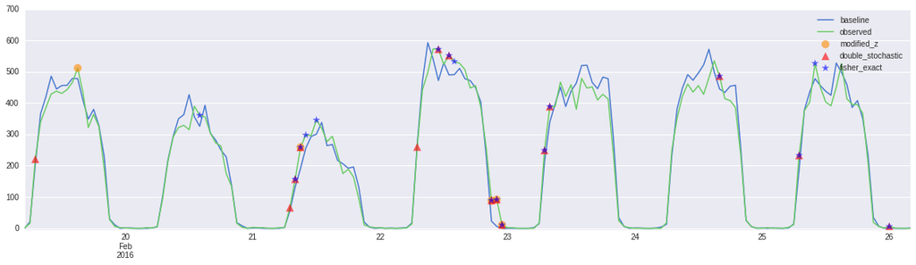

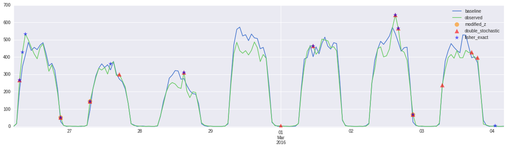

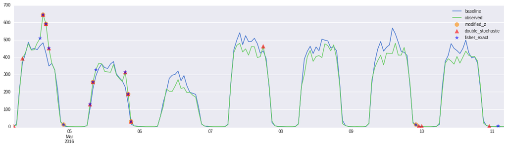

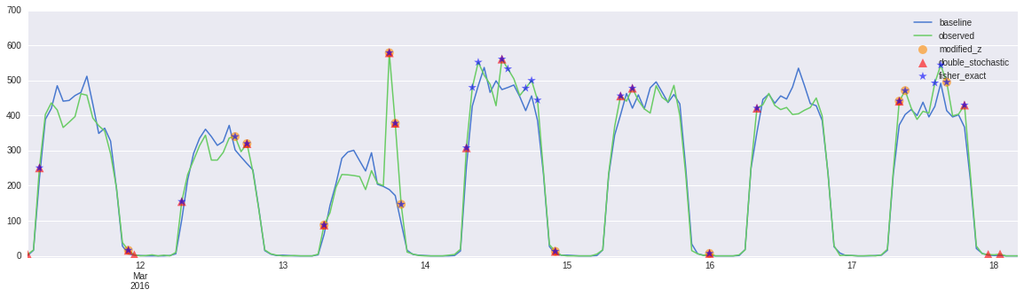

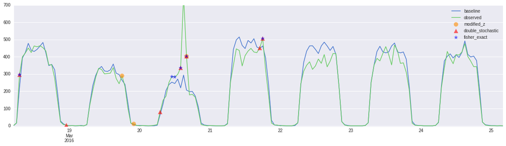

```python
symbols = {'fisher_exact':('b','*',2.3),'modified_z':('darkorange','o',4.0),'double_stochastic':('r','^',4.3)}
start = 24*7*5
weeks = 6
scale = 168
top = 10
for i in range(start,start+scale*weeks,scale):
    keep = data.iloc[i:i+scale]
    ax = keep[['baseline','observed']].plot(figsize=(20,5),linewidth=1.5,alpha=1)
    labels = []
    for method,marker in symbols.items():
        temp = data[data[method]>=marker[2]]['observed'].reset_index()
        ax.scatter(x=[np.datetime_as_string(x) for x in temp['index'].values],y=temp['observed'],s=100,c=marker[0],\
                   marker=marker[1],zorder=10,edgecolors='none',alpha=0.6)
        labels.append(str(method))
    ax.legend(labels=['baseline','observed']+labels)
    ax.set_ylim([-5,700])
```

### A Special Case: Phase Shift

At the onset of spring, one witnesses call arrival patterns that essentially mirror historical arrival rates shifted by one unit in time, i.e. a phase shift. This seems to be a natural consequence of routine shifts in everyday life owing to the change in daylight hours with the demise of winter. In order to reconcile this with the usual definition of an anomaly, one should ensure that these cases are not flagged solely on the basis of the usual "5-week same day/hour" definition of baseline, since the baseline itself is anomalous. It takes atleast 3-weeks for the baseline to absorb this shift leaving behind a phase vulnerable to false alarms. Consequently, all of the current approaches exhibit high sensitivity to this change as they are not designed to handle such scenarios. The question of what and how much consitutes an anomaly here is non-trivial. In order to cope with this, we recommend that the baseline be shifted up in phase by one-unit to maintain the call-arrival patterns. We chose to skip this 4-week period in the above evaluation until the baseline adapts itself to this change. Here is a visual showing this phenomenon, needless to say that all the methods fail to acknowledge the phase shifts:

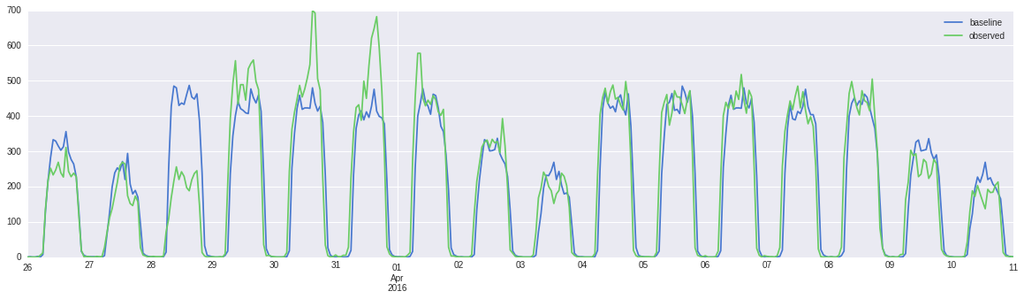

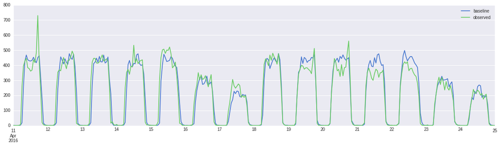

```python
start,mid,halt = '2016-03-26 00:00:00', '2016-04-11 00:00:00', '2016-04-25 00:00:00'
aggregate.ix[start:mid][['baseline','observed']].plot(figsize=(20,5))
aggregate.ix[mid:halt][['baseline','observed']].plot(figsize=(20,5))
```

## References

- https://en.wikipedia.org/wiki/Online_algorithm
- https://en.wikipedia.org/wiki/Interquartile_range
- https://en.wikipedia.org/wiki/Box_plot
- Leys, C., et al., Detecting outliers: Do not use standard deviation around the mean, use absolute deviation around the median, Journal of Experimental Social Psychology (2013), http://dx.doi.org/10.1016/j.jesp.2013.03.013
- Detection of Outliers: http://www.itl.nist.gov/div898/handbook/eda/section3/eda35h.htm
- https://en.wikipedia.org/wiki/Fisher's_exact_test
- Modified z-scores from IBM SPSS: http://www.ibm.com/support/knowledgecenter/SSWLVY_1.0.0/com.ibm.spss.analyticcatalyst.help/analytic_catalyst/modified_z.html
- A Review and Comparison of Methods for Detecting Outliers in Univariate Data Sets, Songwon Seo, BS Thesis, Kyunghee University, 2002 http://d-scholarship.pitt.edu/7948/1/Seo.pdf
- https://en.wikipedia.org/wiki/Medcouple
- M. Hubert, E. Vandervieren, An adjusted boxplot for skewed distributions, Computational Statistics & Data Analysis, Volume 52, Issue 12, 15 August 2008, Pages 5186-5201, ISSN 0167-9473, http://www.sciencedirect.com/science/article/pii/S0167947307004434
- Avramidis, A. N., A. Deslauriers, and P. L’Ecuyer. 2004. “Modeling Daily Arrivals to a Telephone Call Center”. Management Science 50 (7): 896–908. https://www.researchgate.net/publication/220534764_Modeling_Daily_Arrivals_to_a_Telephone_Call_Center
- Owen Vallis, Jordan Hochenbaum, and Arun Kejariwal. 2014. A novel technique for long-term anomaly detection in the cloud. In Proceedings of the 6th USENIX conference on Hot Topics in Cloud Computing (HotCloud'14). USENIX Association, Berkeley, CA, USA, 15-15. https://www.usenix.org/system/files/conference/hotcloud14/hotcloud14-vallis.pdf

```python
from IPython.display import HTML

HTML('''<script>
code_show=true;
function code_toggle() {
 if (code_show){
 $('div.input').hide();
 } else {
 $('div.input').show();
 }
 code_show = !code_show
}
$( document ).ready(code_toggle);
</script>
<form action="javascript:code_toggle()"><input type="submit" value="Click here to toggle on/off the raw code."></form>''')
```